# SPEW Output Summary

Synthetic Populations and Ecosystems of the World

[figure not shown]

# ARKANSAS

There is/are 2 level(s) of nested ecosystems in Arkansas.

There is/are 685 lowest level subregions.

## Data

The raw counts, microdata, and shapefiles are from the US Census.

## Maps

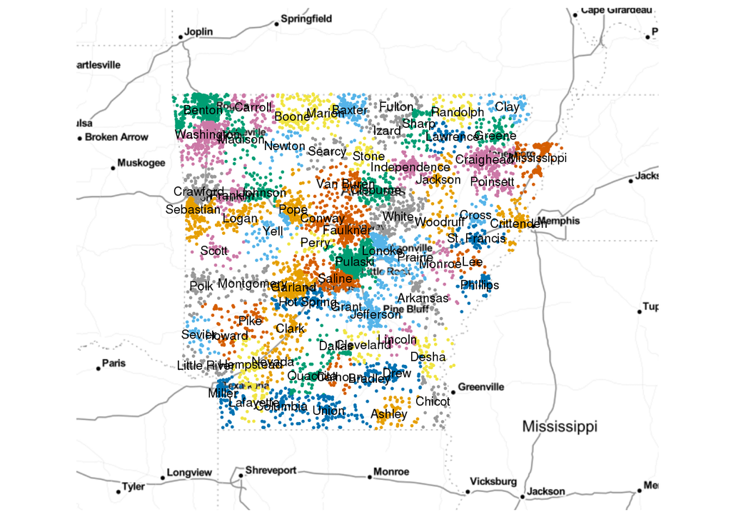

The above map shows a sub-sample of the different sub regions. Each region has a sample of up to 10,000 households.

## Synthetic Households

**Total Synthetic Households:** 1,300,449

### Summaries

Below is a bar chart of the number of households in each region.

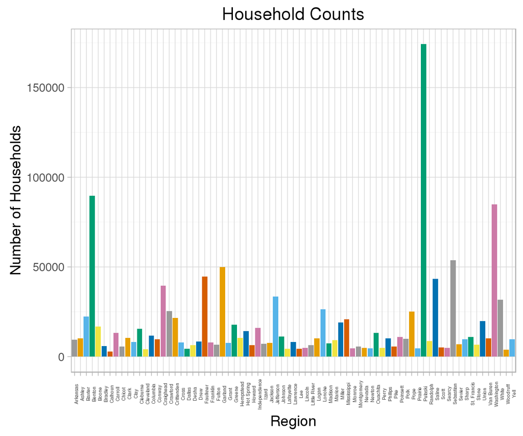

### Column Names

There are 158 columns in the synthetic household ecosystem. They are:

```
##   [1] "RT"          "SERIALNO"    "DIVISION"    "puma"        "id"
##   [6] "REGION"      "ST"          "ADJHSG"      "ADJINC"      "WGTP"
##  [11] "NP"          "TYPE"        "ACCESS"      "ACR"         "AGS"
##  [16] "BATH"        "BDSP"        "BLD"         "BROADBND"    "BUS"
##  [21] "COMPOTHX"    "CONP"        "DIALUP"      "DSL"         "ELEP"
##  [26] "FIBEROP"     "FS"          "FULP"        "GASP"        "HANDHELD"
##  [31] "HFL"         "INSP"        "LAPTOP"      "MHP"         "MODEM"
##  [36] "MRGI"        "MRGP"        "MRGT"        "MRGX"        "OTHSVCEX"
##  [41] "REFR"        "RMSP"        "RNTM"        "RNTP"        "RWAT"
##  [46] "RWATPR"      "SATELLITE"   "SINK"        "SMP"         "STOV"
##  [51] "TEL"         "TEN"         "TOIL"        "VACS"        "VALP"
##  [56] "VEH"         "WATP"        "YBL"         "FES"         "FFINCP"
##  [61] "FGRNTP"      "FHINCP"      "FINCP"       "FPARC"       "FSMOCP"
##  [66] "GRNTP"       "GRPIP"       "HHL"         "HHT"         "HINCP"
##  [71] "HUGCL"       "HUPAC"       "HUPAOC"      "HUPARC"      "KIT"
```

[output cut: 17 more lines]

## Synthetic Persons

**Total Synthetic Persons:** 2,724,138

### Summaries

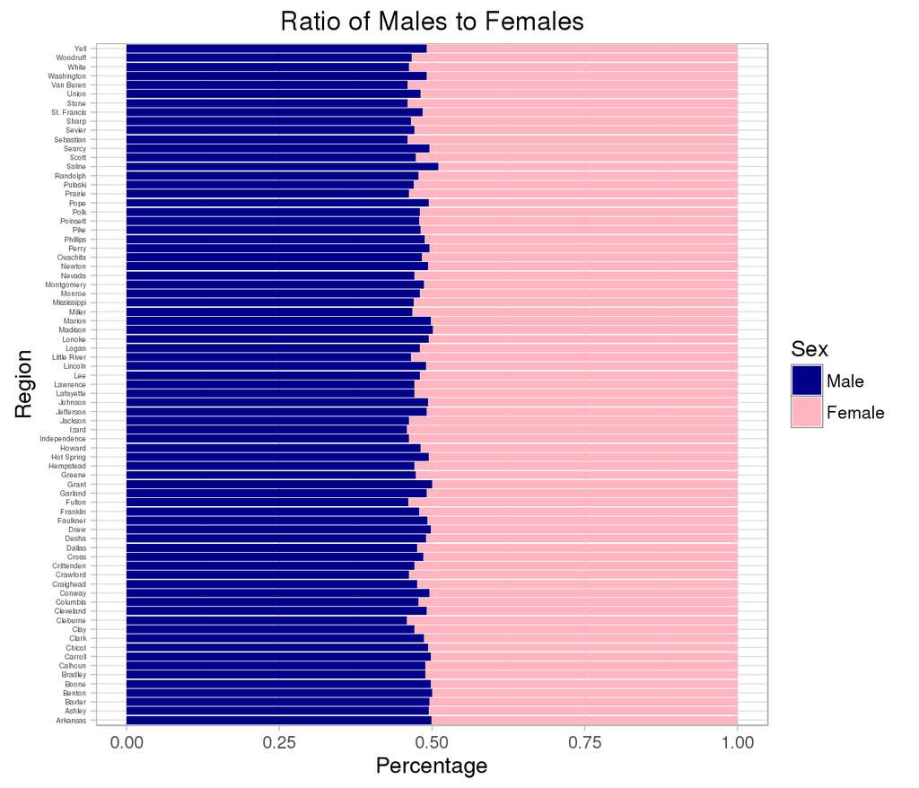

### Column Names

```
##   [1] "RT"          "SERIALNO"    "DIVISION"    "puma"        "id"
##   [6] "REGION"      "ST"          "ADJHSG"      "ADJINC"      "WGTP"
##  [11] "NP"          "TYPE"        "ACCESS"      "ACR"         "AGS"
##  [16] "BATH"        "BDSP"        "BLD"         "BROADBND"    "BUS"
##  [21] "COMPOTHX"    "CONP"        "DIALUP"      "DSL"         "ELEP"
##  [26] "FIBEROP"     "FS"          "FULP"        "GASP"        "HANDHELD"
##  [31] "HFL"         "INSP"        "LAPTOP"      "MHP"         "MODEM"
##  [36] "MRGI"        "MRGP"        "MRGT"        "MRGX"        "OTHSVCEX"
##  [41] "REFR"        "RMSP"        "RNTM"        "RNTP"        "RWAT"
##  [46] "RWATPR"      "SATELLITE"   "SINK"        "SMP"         "STOV"
##  [51] "TEL"         "TEN"         "TOIL"        "VACS"        "VALP"
##  [56] "VEH"         "WATP"        "YBL"         "FES"         "FFINCP"
##  [61] "FGRNTP"      "FHINCP"      "FINCP"       "FPARC"       "FSMOCP"
##  [66] "GRNTP"       "GRPIP"       "HHL"         "HHT"         "HINCP"
##  [71] "HUGCL"       "HUPAC"       "HUPAOC"      "HUPARC"      "KIT"
```

[output cut: 59 more lines]

## Generation Information

This report was generated on 2016-09-29 11:28:58 by `spew`, an `R` package used to generate populations throughout the world. Please see our [spew Github repo](https://github.com/leerichardson/spew) and our previously generated regions at [epimodels.org](http://www.epimodels.org/drupal/?q=node/32). We are a part of the Infomatics Services Group MIDAS branch at Carnegie Mellon University and University of Pittsburgh and are supported by 1 U24 GM110707-01 NIH/NIGMS grant. Please send your comments and suggestions to sventura@stat.cmu.edu.